# NGS and data analysis – final report

Konstancja Gałat

January 23 2024

# Introduction

Next Generation Sequencing (NGS) encompasses a set of techniques designed for the acquisition and examination of genomic and transcriptomic data. The forthcoming report will concentrate on the analysis of transcriptomic data, with a specific emphasis on RNA sequencing.

# Analysis

## Installing required packages

```r
# install.packages("BiocManager") # library for management of bioconductor env
# BiocManager::install("Rsubread") # Read aligning and mapping
# BiocManager::install("edgeR") # Differential Expression for advanced
# BiocManager::install("limma") # Microarray-like approach
# BiocManager::install("DESeq2") # Differential Expression for dummies
```

```r
library(Rsubread)
library(edgeR)
library(limma)
library(DESeq2)
```

## Visualisation

Merged information about genes and transcripts (data.RData file) was loaded into the environment.

```r
load("data.RData")
head(genes.merged)
```

```
##              OE_1_R1   OE_1_R2      WT_R1     WT_R2
## AT1G01010   83.67335  85.17584  142.17310 107.61582
## AT1G01020   92.67743  94.69578  102.60970 112.07213
## AT1G01030   72.16055  41.87812   44.05542  44.99994
## AT1G01040  348.68411 432.42489  324.89535 425.37966
## AT1G01050  221.20927 157.71952  334.07581 158.77768
## AT1G01060 2283.61246 471.58908 1028.13074 719.83060
```

```r
head(trans.merged)
```

```
##                 OE_1_R1  OE_1_R2      WT_R1     WT_R2
## AT1G01010_ID1 83.673351 85.17584 142.173100 107.61582
## AT1G01020_ID8  8.750743 18.41270  21.360060  20.55019
## AT1G01020_ID9 37.910036 21.36570  22.675898  33.39722
## AT1G01020_ID4  9.650110 14.02244   8.363400  15.10687
## AT1G01020_ID5 11.817266 14.21590   8.250928  17.22066
## AT1G01020_ID6  8.541985 16.20686   9.877057   9.85386
```

Batch plots were created in order to get an overview of relations between samples. Each point on each plot represents a single genomic site and has X and Y values equal to logarithm of relevant counts.

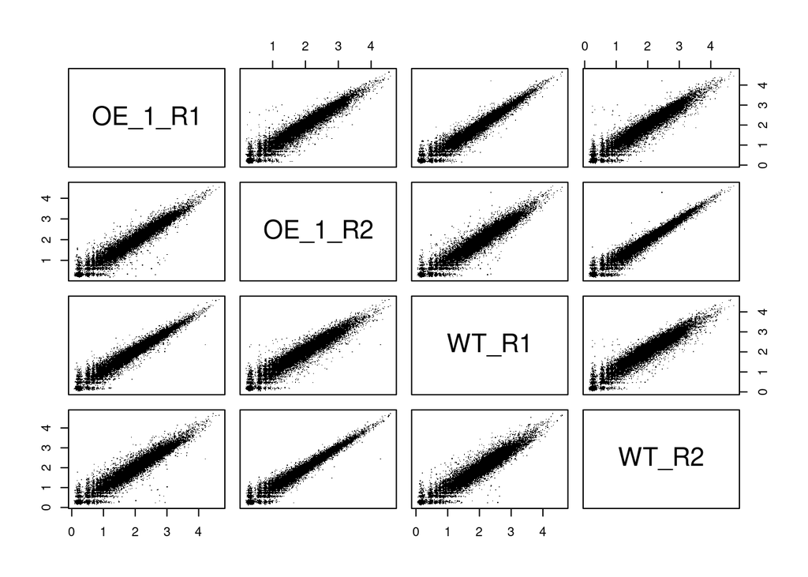

```r
pairs(log10(genes.merged+0.1), pch='.')
```

Alternative transcripts for AT3G01150 were found.

```r
T2G <- data.frame(transID = rownames(trans.merged), geneID = substr(rownames(trans.merged), 0, 9))
rownames(T2G) <- T2G$transID
head(T2G)
```

|  | transID | geneID |
| --- | --- | --- |
| AT1G01010_ID1 | AT1G01010_ID1 | AT1G01010 |
| AT1G01020_ID8 | AT1G01020_ID8 | AT1G01020 |
| AT1G01020_ID9 | AT1G01020_ID9 | AT1G01020 |
| AT1G01020_ID4 | AT1G01020_ID4 | AT1G01020 |
| AT1G01020_ID5 | AT1G01020_ID5 | AT1G01020 |
| AT1G01020_ID6 | AT1G01020_ID6 | AT1G01020 |

```r
T2G[T2G$geneID == 'AT3G01150',]
```

|  | transID | geneID |
| --- | --- | --- |
| AT3G01150_ID3 | AT3G01150_ID3 | AT3G01150 |
| AT3G01150_ID4 | AT3G01150_ID4 | AT3G01150 |
| AT3G01150_ID1 | AT3G01150_ID1 | AT3G01150 |
| AT3G01150_ID2 | AT3G01150_ID2 | AT3G01150 |

Smooth scatter (heatmap) plots comparing WT to OE were created.

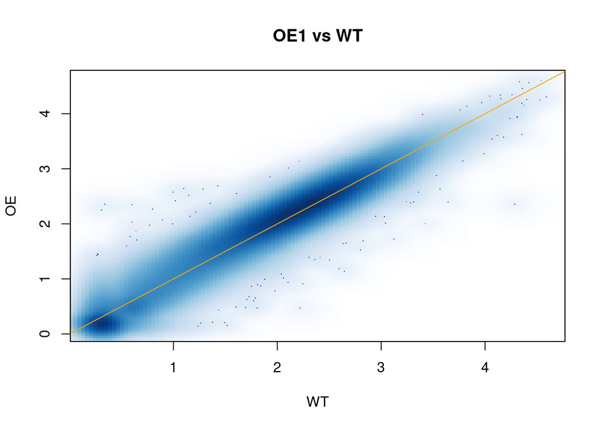

```r
smoothScatter(log10(genes.merged[,2] + 0.1), log10(genes.merged[,3] + 0.1),
     main='OE1 vs WT', xlab="WT", ylab="OE", pch='.', col='blue')
abline(a=0, b=1, col='orange')
```

AT3G01150 locus was emphasized on the scatter plot as an example. It is depicted with a magenta X on the figure below.

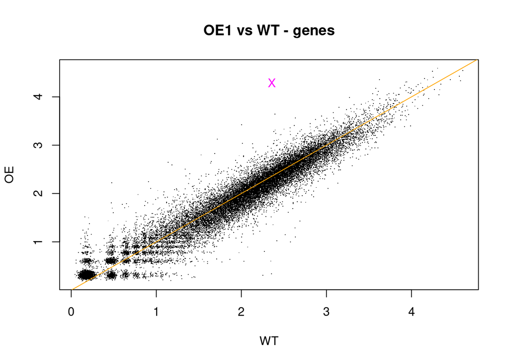

```r
sel.g <- "AT3G01150"
cols <- rep("black", dim(genes.merged)[1])
pchs <- rep(".", dim(genes.merged)[1])

names(cols) <- names(pchs) <- rownames(genes.merged)
cols[sel.g] <- "magenta"
pchs[sel.g] <- "X"

plot(log10(genes.merged[,3] + 0.1), log10(genes.merged[,2] + 0.1),
     main='OE1 vs WT - genes', xlab="WT", ylab="OE", pch=pchs, col=cols,)
abline(a=0, b=1, col='orange')
```

The same thing was done for the transcripts data.

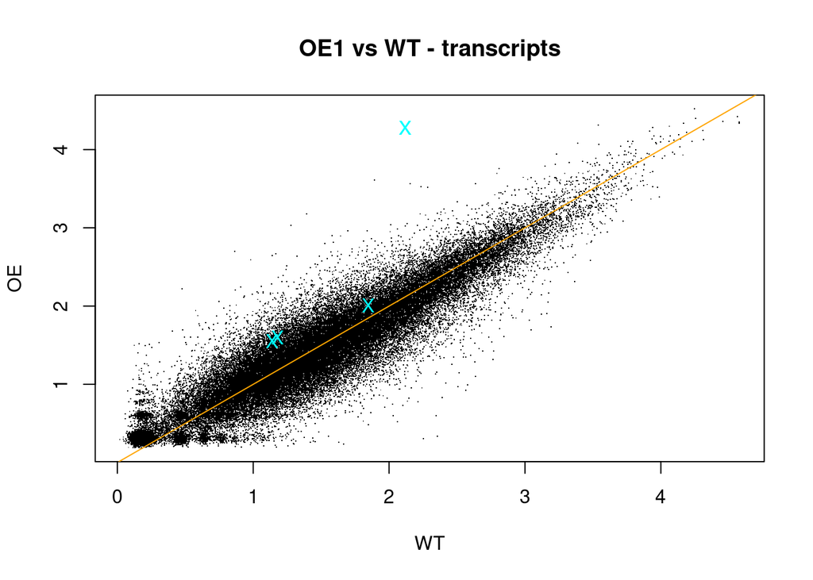

```r
sel.t <- T2G$transID[T2G$geneID == sel.g]
cols <- rep("black", dim(trans.merged)[1])
pchs <- rep(".", dim(trans.merged)[1])
names(cols) <- names(pchs) <- rownames(trans.merged)
cols[sel.t] <- "cyan"
pchs[sel.t] <- "X"

plot(log10(trans.merged[,3] + 0.1), log10(trans.merged[,2] + 0.1),
     main='OE1 vs WT - transcripts', xlab="WT", ylab="OE", pch=pchs, col=cols)
points(log10(trans.merged[sel.t,3] + 0.1), log10(trans.merged[sel.t,2] + 0.1), pch="X", col="cyan")
abline(a=0, b=1, col='orange')
```

It turned out that there are 4 different transcripts (variants) corresponding to the AT3G01150 gene.

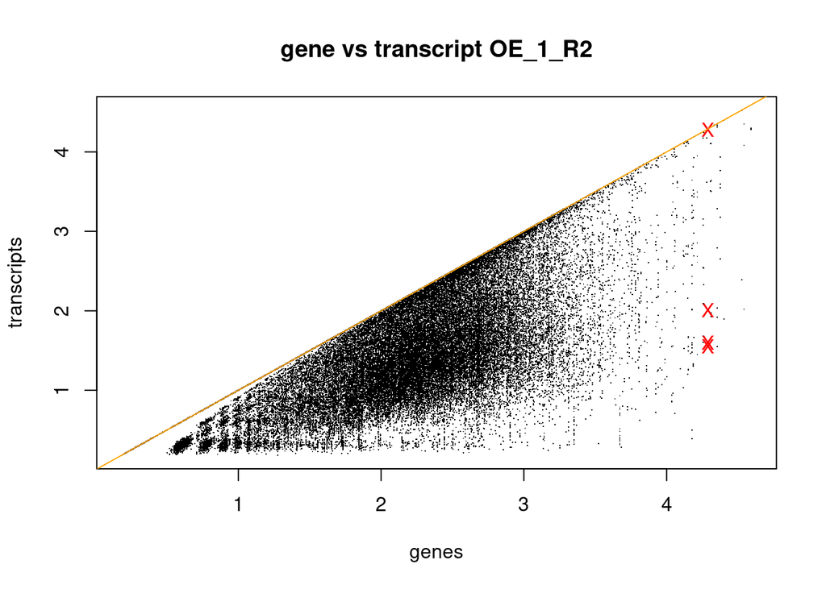

```r
sel.t <- T2G$transID[T2G$geneID == sel.g]
cols <- rep("black", dim(trans.merged)[1])
pchs <- rep(".", dim(trans.merged)[1])
names(cols) <- names(pchs) <- rownames(trans.merged)
cols[sel.t] <- "red"
pchs[sel.t] <- "X"

plot(log10(genes.merged[T2G$geneID,2] + 0.1), log10(trans.merged[,2] + 0.1),
     main='gene vs transcript OE_1_R2', xlab="genes", ylab="transcripts", pch=pchs, col=cols)
abline(a=0, b=1, col='orange')
```

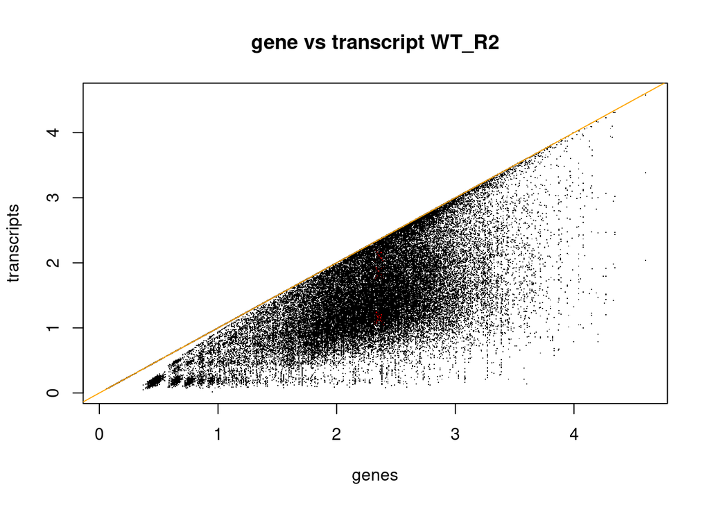

```r
plot(log10(genes.merged[T2G$geneID,3] + 0.1), log10(trans.merged[,3] + 0.1),
     main='gene vs transcript WT_R2', xlab="genes", ylab="transcripts", pch=pchs, col=cols)
abline(a=0, b=1, col='orange')
```

## DGE for genes with limma

All samples were split into two categories: OE and WT and contrasts between the two were defined as cm variable using limma.

```r
samples <- substr(colnames(genes.merged), 0, 2)
design <- data.frame(OEs=ifelse(samples=="OE", 1, 0),
                     WTs=ifelse(samples=="WT", 1, 0))

rownames(design) <- colnames(genes.merged)
design
```

|  | OEs | WTs |
| --- | --- | --- |
| OE_1_R1 | 1 | 0 |
| OE_1_R2 | 1 | 0 |
| WT_R1 | 0 | 1 |
| WT_R2 | 0 | 1 |

```r
cm <- makeContrasts(OEvsWT=OEs-WTs,
                    levels=design)
cm
```

```
##       Contrasts
## Levels OEvsWT
##    OEs      1
##    WTs     -1
```

Initially, the identification of differentially expressed genes was conducted, and the results were stored in the variable ‘dge.’ Subsequent to this, normalization was carried out using the ‘edgeR::calcNormFactors()’ function, implementing TMM normalization. TMM normalization adjusts library sizes by assuming that the majority of genes are not differentially expressed, ensuring the comparability of expression values across sequences.

The creation of a multidimensional matrix containing weight values was facilitated by the ‘limma::voom()’ transformation. These weights were then applied in the ‘limma::lmFit()’ function to establish a linear model. Following this, ‘limma::contrasts.fit()’ was employed to compute coefficients for a given matrix and design. To smooth out standard errors, Bayes correction was applied through ‘limma::eBayes.’

Subsequently, ‘limma::topTable()’ generated a table highlighting the top-rated genes. The Benjamini-Hochberg method was employed for $p$-value correction, aiming to mitigate potential false positives. Finally, genes with adjusted $p$-values below 0.05 were selected.

```r
dge <- DGEList(counts=genes.merged)
names(dge)
```

```
## [1] "counts"  "samples"
```

```r
dge <- calcNormFactors(dge)
dge$samples
```

|  | group | lib.size | norm.factors |
| --- | --- | --- | --- |
| OE_1_R1 | 1 | 7908292 | 0.9971111 |
| OE_1_R2 | 1 | 7536655 | 1.0153601 |
| WT_R1 | 1 | 7797561 | 1.0350277 |
| WT_R2 | 1 | 7970894 | 0.9542988 |

```r
v <- voom(dge, design, plot=FALSE)
names(v)
```

```
## [1] "targets" "E"       "weights" "design"
```

```r
summary(genes.merged)
```

```
##     OE_1_R1            OE_1_R2             WT_R1              WT_R2
##  Min.   :    1.11   Min.   :    1.43   Min.   :    1.01   Min.   :    1.27
##  1st Qu.:   15.97   1st Qu.:   16.32   1st Qu.:   19.63   1st Qu.:   16.54
##  Median :   99.14   Median :   93.21   Median :  108.21   Median :   92.47
##  Mean   :  330.82   Mean   :  315.28   Mean   :  326.19   Mean   :  333.44
##  3rd Qu.:  307.97   3rd Qu.:  288.51   3rd Qu.:  312.32   3rd Qu.:  293.76
##  Max.   :43984.24   Max.   :39150.42   Max.   :40276.70   Max.   :53040.35
```

```r
summary(v$E)
```

```
##     OE_1_R1          OE_1_R2           WT_R1            WT_R2
##  Min.   :-2.295   Min.   :-1.987   Min.   :-2.417   Min.   :-2.107
##  1st Qu.: 1.062   1st Qu.: 1.137   1st Qu.: 1.319   1st Qu.: 1.163
##  Median : 3.659   Median : 3.614   Median : 3.752   Median : 3.611
##  Mean   : 3.173   Mean   : 3.197   Mean   : 3.223   Mean   : 3.207
##  3rd Qu.: 5.290   3rd Qu.: 5.239   3rd Qu.: 5.276   3rd Qu.: 5.274
##  Max.   :12.446   Max.   :12.321   Max.   :12.285   Max.   :12.768
```

```r
f.t <- lmFit(v, design)
cf <- contrasts.fit(f.t, cm)
fe <- eBayes(cf, proportion=0.01)

# multiple testing correction
adj.method="BH"
limma.countTMMvoom.genes <- topTable(fe, number=Inf, adjust.method=adj.method,
                                  sort.by='none',)
head(limma.countTMMvoom.genes)
```

|  | logFC | AveExpr | t | P.Value | adj.P.Val | B |
| --- | --- | --- | --- | --- | --- | --- |
| AT1G01010 | -0.53794542 | 3.718514 | -1.6078652 | 0.1499230 | 0.9999874 | -4.509940 |
| AT1G01020 | -0.18055216 | 3.690605 | -0.5493838 | 0.5990546 | 0.9999874 | -4.651710 |
| AT1G01030 | 0.31707773 | 2.679654 | 0.7414928 | 0.4814453 | 0.9999874 | -4.622397 |
| AT1G01040 | 0.07503273 | 5.607778 | 0.2333715 | 0.8218495 | 0.9999874 | -4.693731 |
| AT1G01050 | -0.29063991 | 4.736211 | -0.7177476 | 0.4951213 | 0.9999874 | -4.645332 |
| AT1G01060 | 0.28077141 | 6.921076 | 0.4254800 | 0.6826871 | 0.9999874 | -4.671404 |

```r
sum(limma.countTMMvoom.genes$adj.P.Val<0.05)
```

```
## [1] 1
```

```r
limma.countTMMvoom.genes[limma.countTMMvoom.genes$adj.P.Val<0.05,]
```

|  | logFC | AveExpr | t | P.Value | adj.P.Val | B |
| --- | --- | --- | --- | --- | --- | --- |
| AT3G01150 | 6.123485 | 8.084137 | 16.10867 | 5.403837e-07 | 0.01291787 | -4.100763 |

```r
limma.countTMMvoom.genes[sel.g,]
```

|  | logFC | AveExpr | t | P.Value | adj.P.Val | B |
| --- | --- | --- | --- | --- | --- | --- |
| AT3G01150 | 6.123485 | 8.084137 | 16.10867 | 5.403837e-07 | 0.01291787 | -4.100763 |

Only one gene (AT3G01150) was significantly differentiating. This gene was indicated using a red * on a MA plot of OE vs WT below. Additionally volcano plot was created.

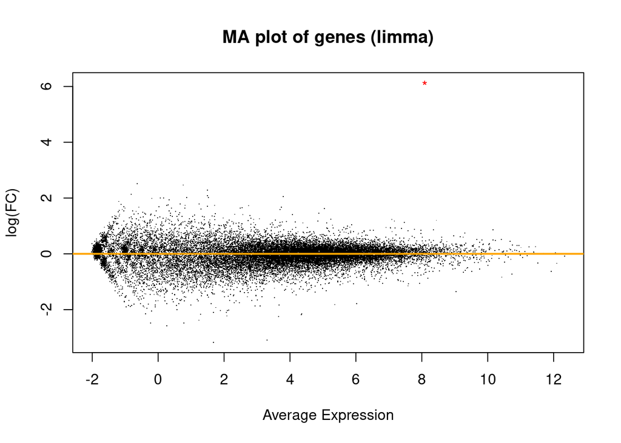

```r
pchs <- rep(".", dim(limma.countTMMvoom.genes)[1])
colors <- rep("black", dim(limma.countTMMvoom.genes)[1])
names(pchs) <- names(colors) <- rownames(limma.countTMMvoom.genes)
pchs[sel.g] <- "*"
colors[sel.g] <- "red"
plot(
limma.countTMMvoom.genes$AveExpr,
limma.countTMMvoom.genes$logFC,
col = colors,
pch = pchs,
xlab = "Average Expression",
ylab = "log(FC)",
main="MA plot of genes (limma)",
)
abline(h=0, col = "orange", lwd = 2)
```

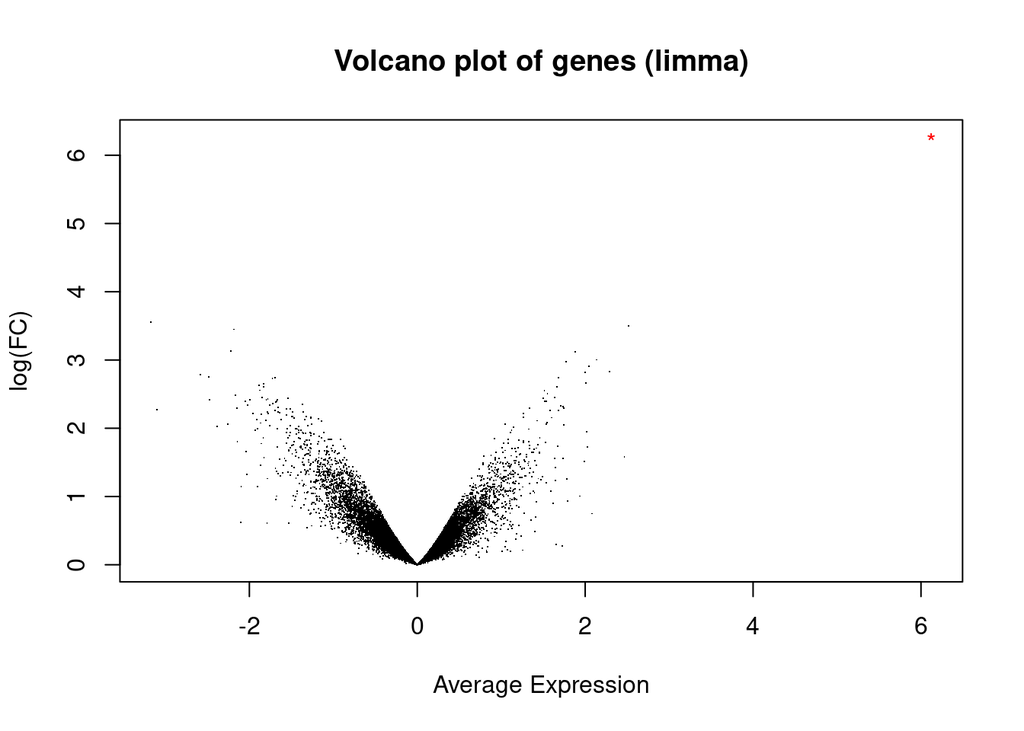

```r
plot(
limma.countTMMvoom.genes$logFC,
-log10(limma.countTMMvoom.genes$P.Value),
col = colors,
pch = pchs,
xlab = "Average Expression",
ylab = "log(FC)",
main="Volcano plot of genes (limma)",
)
```

### DGE for transcripts with limma

The same steps were taken, but this time, transcripts data was used.

```r
dge <- DGEList(counts=trans.merged)
names(dge)
```

```
## [1] "counts"  "samples"
```

```r
dge <- calcNormFactors(dge)
dge$samples
```

|  | group | lib.size | norm.factors |
| --- | --- | --- | --- |
| OE_1_R1 | 1 | 7908292 | 0.9861773 |
| OE_1_R2 | 1 | 7536655 | 1.0302895 |
| WT_R1 | 1 | 7797561 | 1.0238564 |
| WT_R2 | 1 | 7970894 | 0.9612729 |

```r
v <- voom(dge, design, plot=FALSE)
names(v)
```

```
## [1] "targets" "E"       "weights" "design"
```

```r
summary(trans.merged)
```

```
##     OE_1_R1            OE_1_R2             WT_R1              WT_R2
##  Min.   :    1.06   Min.   :    1.43   Min.   :    0.95   Min.   :    1.27
##  1st Qu.:    8.11   1st Qu.:    8.39   1st Qu.:    8.87   1st Qu.:    8.21
##  Median :   24.34   Median :   24.66   Median :   26.44   Median :   24.17
##  Mean   :  137.76   Mean   :  131.28   Mean   :  135.83   Mean   :  138.85
##  3rd Qu.:   86.75   3rd Qu.:   84.45   3rd Qu.:   90.98   3rd Qu.:   83.96
##  Max.   :38655.88   Max.   :33305.85   Max.   :37868.56   Max.   :41504.22
```

```r
summary(v$E)
```

```
##     OE_1_R1           OE_1_R2            WT_R1             WT_R2
##  Min.   :-2.3212   Min.   :-2.0085   Min.   :-2.4642   Min.   :-2.117
##  1st Qu.: 0.1428   1st Qu.: 0.1959   1st Qu.: 0.2303   1st Qu.: 0.185
##  Median : 1.6712   Median : 1.6961   Median : 1.7548   Median : 1.687
##  Mean   : 1.8811   Mean   : 1.9029   Mean   : 1.9159   Mean   : 1.901
##  3rd Qu.: 3.4838   3rd Qu.: 3.4516   3rd Qu.: 3.5184   3rd Qu.: 3.462
##  Max.   :12.2751   Max.   :12.0665   Max.   :12.2117   Max.   :12.403
```

```r
f.t <- lmFit(v, design)
cf <- contrasts.fit(f.t, cm)
fe <- eBayes(cf, proportion=0.01)

adj.method="BH"
limma.countTMMvoom.trans <- topTable(fe, number=Inf, adjust.method=adj.method,
                                  sort.by='none',)
head(limma.countTMMvoom.trans)
```

|  | logFC | AveExpr | t | P.Value | adj.P.Val | B |
| --- | --- | --- | --- | --- | --- | --- |
| AT1G01010_ID1 | -0.54242855 | 3.7185140 | -1.15124132 | 0.2802747 | 0.9999965 | -4.587600 |
| AT1G01020_ID8 | -0.69001983 | 1.1104461 | -1.21252523 | 0.2571939 | 0.9999965 | -4.585733 |
| AT1G01020_ID9 | 0.05506893 | 1.8691504 | 0.09441678 | 0.9269158 | 0.9999965 | -4.618065 |
| AT1G01020_ID4 | 0.05099166 | 0.6151374 | 0.09345027 | 0.9276615 | 0.9999965 | -4.622177 |
| AT1G01020_ID5 | 0.11709142 | 0.7309135 | 0.20895226 | 0.8392935 | 0.9999965 | -4.620637 |
| AT1G01020_ID6 | 0.25316511 | 0.5328437 | 0.47884883 | 0.6438458 | 0.9999965 | -4.616095 |

```r
sum(limma.countTMMvoom.trans$adj.P.Val<0.05)
```

```
## [1] 1
```

```r
limma.countTMMvoom.trans[limma.countTMMvoom.trans$adj.P.Val<0.05,]
```

|  | logFC | AveExpr | t | P.Value | adj.P.Val | B |
| --- | --- | --- | --- | --- | --- | --- |
| AT3G01150_ID4 | 6.906772 | 7.675772 | 17.69561 | 3.988909e-08 | 0.002289953 | -4.20909 |

```r
limma.countTMMvoom.trans[sel.t,]
```

|  | logFC | AveExpr | t | P.Value | adj.P.Val | B |
| --- | --- | --- | --- | --- | --- | --- |
| AT3G01150_ID3 | 0.4142790 | 1.284738 | 0.6202899 | 5.509593e-01 | 0.999996518 | -4.609800 |
| AT3G01150_ID4 | 6.9067717 | 7.675772 | 17.6956123 | 3.988909e-08 | 0.002289953 | -4.209090 |
| AT3G01150_ID1 | 0.5932008 | 1.221358 | 0.9732981 | 3.566752e-01 | 0.999996518 | -4.596818 |
| AT3G01150_ID2 | 0.6315154 | 3.647756 | 1.2894979 | 2.304340e-01 | 0.999996518 | -4.579757 |

Only one transcript was significantly differentiating. This transcript was indicated using a red * on a MA plot of OE vs WT below. Additionally volcano plot was created.

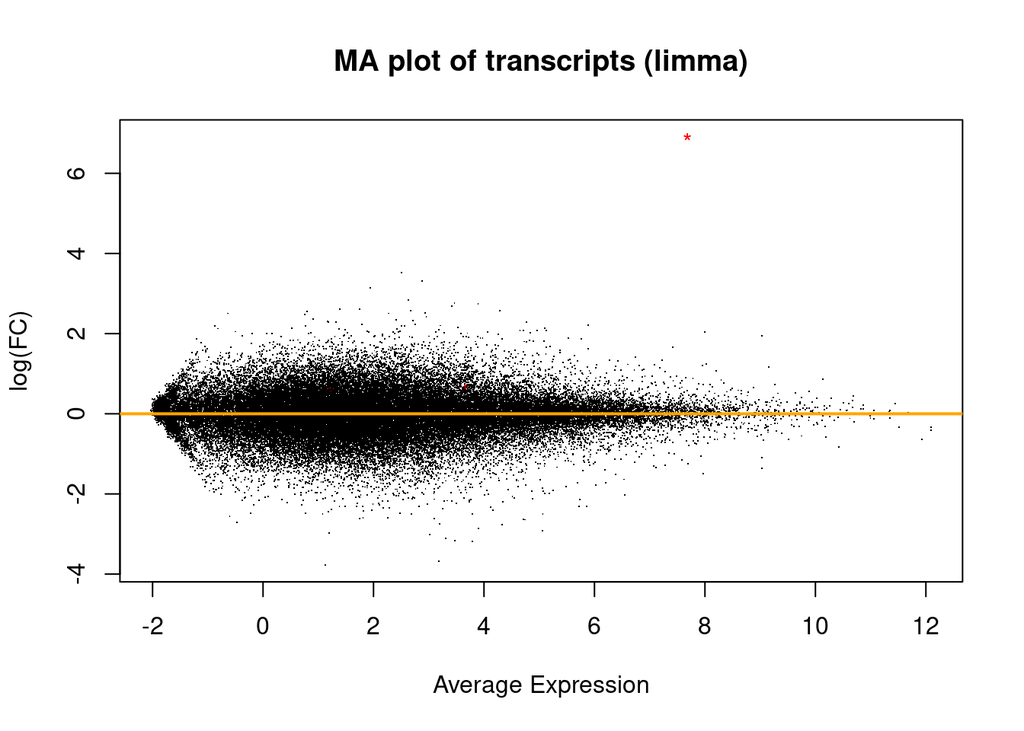

```r
pchs <- rep(".", dim(limma.countTMMvoom.trans)[1])
colors <- rep("black", dim(limma.countTMMvoom.trans)[1])
names(pchs) <- names(colors) <- rownames(limma.countTMMvoom.trans)
pchs[sel.t] <- "*"
colors[sel.t] <- "red"
plot(
limma.countTMMvoom.trans$AveExpr,
limma.countTMMvoom.trans$logFC,
col = colors,
pch = pchs,
xlab = "Average Expression",
ylab = "log(FC)",
main="MA plot of transcripts (limma)",
)
abline(h=0, col = "orange", lwd = 2)
```

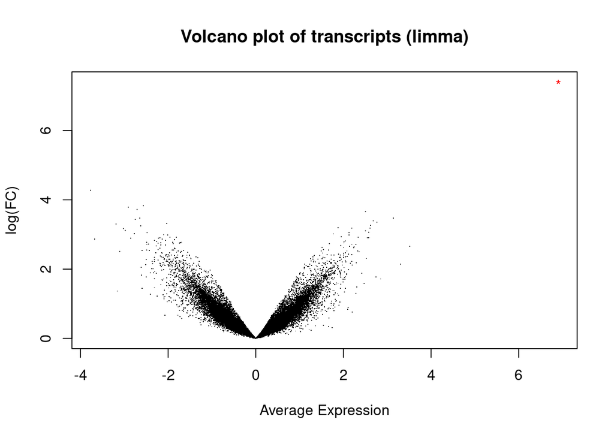

```r
plot(
limma.countTMMvoom.trans$logFC,
-log10(limma.countTMMvoom.trans$P.Val),
col = colors,
pch = pchs,
xlab = "Average Expression",
ylab = "log(FC)",
main="Volcano plot of transcripts (limma)",
)
```

MA plot showing transcripts vs genes was created.

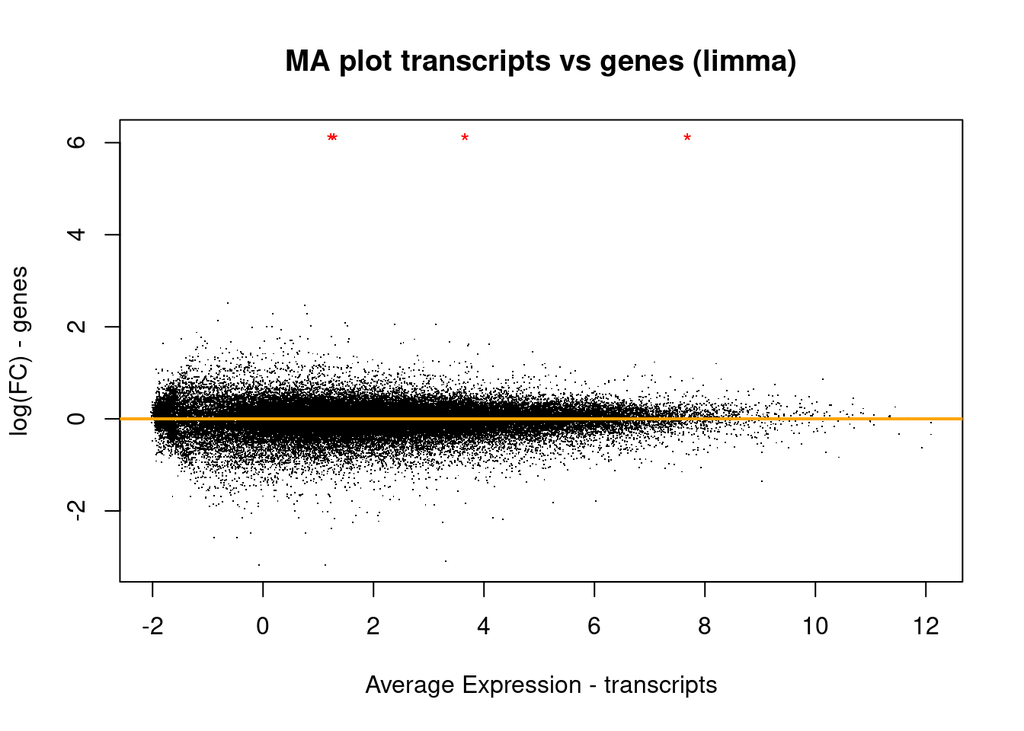

```r
pchs <- rep(".", dim(limma.countTMMvoom.trans)[1])
colors <- rep("black", dim(limma.countTMMvoom.trans)[1])
names(pchs) <- names(colors) <- rownames(limma.countTMMvoom.trans)
pchs[sel.t] <- "*"
colors[sel.t] <- "red"
plot(
limma.countTMMvoom.trans$AveExpr,
limma.countTMMvoom.genes[T2G$geneID,]$logFC,
col = colors,
pch = pchs,
xlab = "Average Expression - transcripts",
ylab = "log(FC) - genes",
main="MA plot transcripts vs genes (limma)",
)
abline(h=0, col = "orange", lwd = 2)
```

## DGE for genes with edgeR

The next step was to construct a DGEList object and run a series of statistical tests using edgeR. Both quasi-likelihood F-test and classic likelihood ratio test were used to determine p-values. MA plots were generated, significantly differentiating genes/transcripts were indicated using a red *.

```r
group <- factor(c("2", "2","1", "1"))
y <- DGEList(counts = genes.merged, group=group)
keep <- filterByExpr(y)
design <- model.matrix(~group)
y <-  estimateDisp(y, design)
```

```r
genes_fit <- glmQLFit(y,design)
genes_qlf <- glmQLFTest(genes_fit, coef=2)
genes.qlf.tT <- topTags(genes_qlf, n=Inf)
```

```r
genes_fit <- glmFit(y,design)
genes_lrt <-  glmLRT(genes_fit, coef=2)
genes.lrt.tT <- topTags(genes_lrt, n=Inf)
```

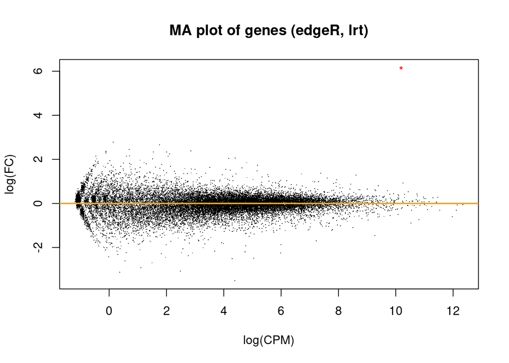

```r
pchs <- rep(".", dim(genes.lrt.tT$table)[1])
colors <- rep("black", dim(genes.lrt.tT$table)[1])
names(pchs) <- names(colors) <- rownames(genes.lrt.tT$table)
pchs[sel.g] <- "*"
colors[sel.g] <- "red"
plot(
genes.lrt.tT$table$logCPM,
genes.lrt.tT$table$logFC,
col = colors,
pch = pchs,
xlab = "log(CPM)",
ylab = "log(FC)",
main="MA plot of genes (edgeR, lrt)",
)
abline(h=0, col = "orange", lwd = 2)
```

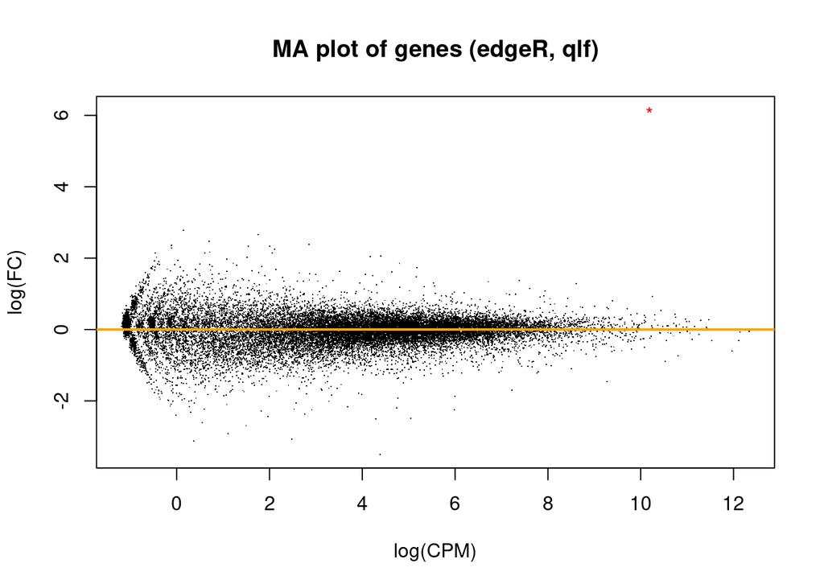

```r
pchs <- rep(".", dim(genes.qlf.tT$table)[1])
colors <- rep("black", dim(genes.qlf.tT$table)[1])
names(pchs) <- names(colors) <- rownames(genes.qlf.tT$table)
pchs[sel.g] <- "*"
colors[sel.g] <- "red"
plot(
genes.qlf.tT$table$logCPM,
genes.qlf.tT$table$logFC,
col = colors,
pch = pchs,
xlab = "log(CPM)",
ylab = "log(FC)",
main="MA plot of genes (edgeR, qlf)",
)
abline(h=0, col = "orange", lwd = 2)
```

## DGE for transcripts with edgeR

The same steps were taken but this time the data for the transcripts was used.

```r
z <- DGEList(counts = trans.merged, group=group)
keep <- filterByExpr(z)
z <-  estimateDisp(z, design)
```

```r
trans_fit <- glmQLFit(z,design)
trans_qlf <- glmQLFTest(trans_fit, coef=2)
trans.qlf.tT <- topTags(trans_qlf, n=Inf)
```

```r
trans_fit_lh <- glmFit(z,design)
trans_lrt <-  glmLRT(trans_fit, coef=2)
trans.lrt.tT <- topTags(trans_lrt, n=Inf)
```

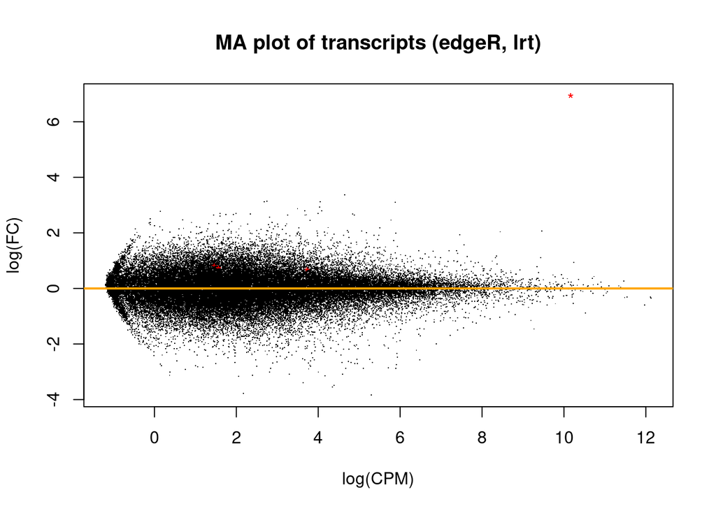

```r
pchs <- rep(".", dim(trans.lrt.tT$table)[1])
colors <- rep("black", dim(trans.lrt.tT$table)[1])
names(pchs) <- names(colors) <- rownames(trans.lrt.tT$table)
pchs[sel.t] <- "*"
colors[sel.t] <- "red"
plot(
trans.lrt.tT$table$logCPM,
trans.lrt.tT$table$logFC,
col = colors,
pch = pchs,
xlab = "log(CPM)",
ylab = "log(FC)",
main="MA plot of transcripts (edgeR, lrt)",
)
abline(h=0, col = "orange", lwd = 2)
```

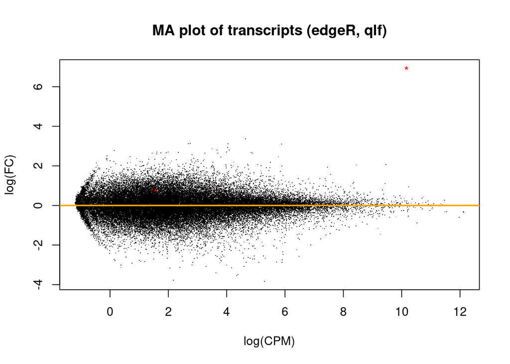

```r
pchs <- rep(".", dim(trans.qlf.tT$table)[1])
colors <- rep("black", dim(trans.qlf.tT$table)[1])
names(pchs) <- names(colors) <- rownames(trans.qlf.tT$table)
pchs[sel.t] <- "*"
colors[sel.t] <- "red"
plot(
trans.qlf.tT$table$logCPM,
trans.qlf.tT$table$logFC,
col = colors,
pch = pchs,
xlab = "log(CPM)",
ylab = "log(FC)",
main="MA plot of transcripts (edgeR, qlf)",
)
abline(h=0, col = "orange", lwd = 2)
```

```r
head(genes.lrt.tT)
```

```
## Coefficient:  group2
##               logFC    logCPM        LR       PValue          FDR
## AT3G01150  6.145698 10.184704 133.70922 6.325314e-31 1.512066e-26
## AT5G35935 -3.076058  2.483950  27.05814 1.974268e-07 2.359744e-03
## AT3G12500 -2.191577  4.746370  24.94876 5.887424e-07 4.691296e-03
## AT1G43800 -3.496196  4.381847  20.40653 6.261586e-06 3.733070e-02
## AT1G48750 -2.229456  2.527363  19.65699 9.266375e-06 3.733070e-02
## AT4G21400  2.041232  4.173641  19.63579 9.369762e-06 3.733070e-02
```

```r
head(genes.qlf.tT)
```

```
## Coefficient:  group2
##               logFC     logCPM        F       PValue       FDR
## AT3G01150  6.145714 10.1847036 89.73483 3.947277e-05 0.9435965
## AT3G12500 -2.191666  4.7463699 40.81367 4.387782e-04 0.9999911
## AT4G10695  2.783286  0.1483811 36.82775 5.922951e-04 0.9999911
## AT2G13570  2.373769 -0.1066467 31.35664 9.392712e-04 0.9999911
## AT4G21400  2.041306  4.1736409 27.25475 1.391160e-03 0.9999911
## AT5G35935 -3.075527  2.4839502 27.14694 1.406508e-03 0.9999911
```

```r
head(trans.lrt.tT)
```

```
## Coefficient:  group2
##                    logFC    logCPM       LR       PValue          FDR
## AT3G01150_ID4   6.934863 10.162096 90.33252 2.013164e-21 1.155717e-16
## AT2G10940_ID2  -3.827998  5.295856 33.46156 7.268628e-09 2.086387e-04
## AT4G19410_ID16 -3.549509  4.350413 26.36528 2.825743e-07 5.374356e-03
## AT1G43800_ID1  -3.496224  4.381787 25.82164 3.744674e-07 5.374356e-03
## AT1G56070_ID1   3.374851  4.640482 25.25499 5.022945e-07 5.767145e-03
## AT2G38170_ID11  3.107720  5.883468 24.62987 6.946651e-07 6.646556e-03
```

```r
head(trans.qlf.tT)
```

```
## Coefficient:  group2
##                     logFC     logCPM         F       PValue        FDR
## AT3G01150_ID4    6.934863 10.1620956 131.08568 8.160694e-07 0.04684891
## AT4G14880_ID19  -2.859165  5.7149248  38.73871 1.305551e-04 0.99999881
## AT4G01800_ID1   -2.668488  5.3173825  34.97735 1.927082e-04 0.99999881
## AT2G36530_ID120  2.802933  4.0868133  31.59074 2.820180e-04 0.99999881
## AT5G10720_ID4   -2.775603  0.1710708  30.90216 3.059298e-04 0.99999881
## AT3G52220_ID3    2.699215  3.9938334  29.68949 3.543335e-04 0.99999881
```

## DGE for genes with DeSeq2

First, the design was created (condition variable), outlining how to model the samples. Subsequently, DeSeq2 was employed to identify significantly different genes. MA plots were generated, significantly differentiationg genes/transcripts were indicated using a red dots.

```r
condition <- factor(c("OE", "OE", "WT", "WT"))
```

```r
condition <- factor(c("OE", "OE", "WT", "WT"))
coldata.genes <- data.frame(row.names = colnames(genes.merged), condition)
dds.genes <- DESeqDataSetFromMatrix(
countData = round(genes.merged),
colData = coldata.genes,
design = ~condition
)
dds.genes <- DESeq(dds.genes)
res.genes <- results(dds.genes)
```

```r
genes.res.v1 <- results(dds.genes, name = "condition_WT_vs_OE")
```

```r
genes.res.v1[genes.res.v1$padj<0.05, ]
```

```
## log2 fold change (MLE): condition WT vs OE
## Wald test p-value: condition WT vs OE
## DataFrame with 4 rows and 6 columns
##            baseMean log2FoldChange     lfcSE      stat      pvalue        padj
##           <numeric>      <numeric> <numeric> <numeric>   <numeric>   <numeric>
## AT1G43800  156.7394        3.46874  0.634994   5.46263 4.69124e-08 5.60721e-04
## AT3G01150 8962.5890       -6.12153  0.403376 -15.17576 5.11796e-52 1.22345e-47
## AT3G12500  205.8780        2.19566  0.451543   4.86257 1.15870e-06 9.23288e-03
## AT5G35935   41.3868        3.12398  0.666234   4.68901 2.74535e-06 1.64069e-02
```

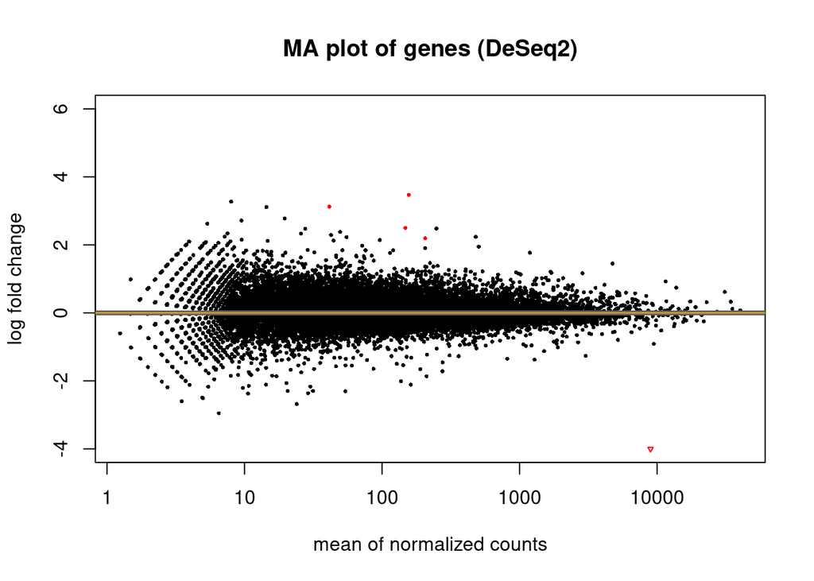

```r
plotMA(genes.res.v1,
       ylim=c(-4,6),
       main = "MA plot of genes (DeSeq2)",
       colNonSig="black",
       colSig="red")
abline(h=0, col = "orange", lwd = 1)
```

## DGE for transcripts with DeSeq2

The same thing was done for the transcripts data.

```r
coldata.trans <- data.frame(row.names = colnames(trans.merged), condition)
dds.trans <- DESeqDataSetFromMatrix(
countData = round(trans.merged),
colData = coldata.trans,
design = ~condition
)
dds.trans <- DESeq(dds.trans)
res.trans <- results(dds.trans)
```

```r
trans.res.v1 <- results(dds.trans, name = "condition_WT_vs_OE")
```

```r
trans.res.v1$padj <- p.adjust(trans.res.v1$pvalue, method = "BH")
trans.res.v1[trans.res.v1$padj<0.05, ]
```

```
## log2 fold change (MLE): condition WT vs OE
## Wald test p-value: condition WT vs OE
## DataFrame with 11 rows and 6 columns
##                  baseMean log2FoldChange     lfcSE      stat      pvalue
##                 <numeric>      <numeric> <numeric> <numeric>   <numeric>
## AT1G43800_ID1    158.6156        3.48572  0.737661   4.72536 2.29704e-06
## AT2G36530_ID120  129.8722       -2.79377  0.601062  -4.64805 3.35080e-06
## AT3G01150_ID4   8822.4028       -6.91216  0.541521 -12.76436 2.59274e-37
## AT3G10970_ID10   105.7362        2.77245  0.601367   4.61024 4.02205e-06
## AT3G52220_ID3    121.0696       -2.70756  0.590609  -4.58436 4.55375e-06
## AT4G01800_ID1    307.5820        2.68073  0.570074   4.70242 2.57092e-06
## AT4G14880_ID12   188.1181        3.09163  0.653472   4.73109 2.23322e-06
## AT4G14880_ID19   406.8757        2.86862  0.578275   4.96066 7.02559e-07
## AT4G19410_ID16   158.6573        3.57903  0.772609   4.63240 3.61453e-06
## AT4G24440_ID7     49.9693       -3.10174  0.699411  -4.43479 9.21605e-06
## AT5G35935_ID1     33.2163        3.78266  0.802189   4.71542 2.41210e-06
##                        padj
##                   <numeric>
## AT1G43800_ID1   2.45986e-02
## AT2G36530_ID120 2.56553e-02
## AT3G01150_ID4   1.48844e-32
## AT3G10970_ID10  2.56553e-02
## AT3G52220_ID3   2.61422e-02
## AT4G01800_ID1   2.45986e-02
## AT4G14880_ID12  2.45986e-02
## AT4G14880_ID19  2.01662e-02
## AT4G19410_ID16  2.56553e-02
## AT4G24440_ID7   4.80977e-02
## AT5G35935_ID1   2.45986e-02
```

```r
sum(trans.res.v1$padj<0.05)
```

```
## [1] 11
```

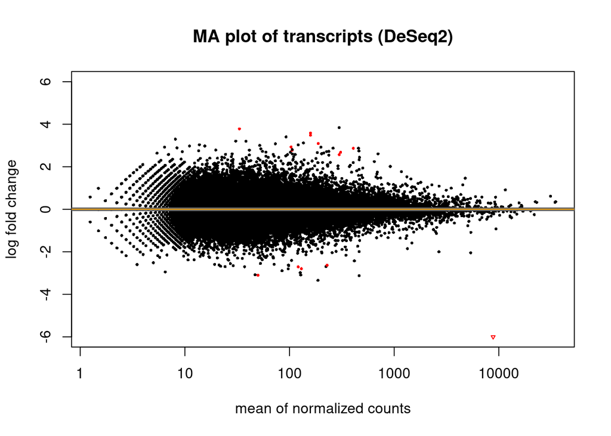

```r
plotMA(trans.res.v1,
       ylim=c(-6,6),
       main = "MA plot of transcripts (DeSeq2)",
       colNonSig="black",
       colSig="red")
abline(h=0, col = "orange", lwd = 1)
```

When using DESeq2 the results are 4 significantly differentiating genes and 11 transcripts.

# Conclusions

## Discussion

The observed discrepancy highlights that the expected results were achieved solely through the limma method. Other methods either proved overly restrictive or prone to false positives. This experiment underscores the non-trivial nature of selecting an appropriate method when dealing with a limited number of replicates. It is crucial to emphasize the necessity of testing multiple methods since, under typical circumstances, the expected outcomes are uncertain.